**Exercise for Artificial Neural Networks / Regression**

By Prof. Seungchul Lee  
http://iai.postech.ac.kr/  
Industrial AI Lab at POSTECH

# Table of Contents

```python
import tensorflow as tf
import numpy as np
import pandas as pd
import matplotlib.pyplot as plt
import matplotlib
import time
import os
```

# 1. Problem Definition

In this tutorial, our data is composed to 1460 row with 81 features. 38 continuous features and 43 categorical features. As exposed in the introduction we will use only the continuous features to build our first model.

House Prices Dataset

# 2. Load Data

```python
train = pd.read_csv('./data_files/HousePrice_train.csv')
train
```

|  | Id | MSSubClass | MSZoning | LotFrontage | LotArea | Street | Alley | LotShape | LandContour | Utilities | ... | PoolArea | PoolQC | Fence | MiscFeature | MiscVal | MoSold | YrSold | SaleType | SaleCondition | SalePrice |
| --- | --- | --- | --- | --- | --- | --- | --- | --- | --- | --- | --- | --- | --- | --- | --- | --- | --- | --- | --- | --- | --- |
| 0 | 1 | 60 | RL | 65.0 | 8450 | Pave | NaN | Reg | Lvl | AllPub | ... | 0 | NaN | NaN | NaN | 0 | 2 | 2008 | WD | Normal | 208500 |
| 1 | 2 | 20 | RL | 80.0 | 9600 | Pave | NaN | Reg | Lvl | AllPub | ... | 0 | NaN | NaN | NaN | 0 | 5 | 2007 | WD | Normal | 181500 |
| 2 | 3 | 60 | RL | 68.0 | 11250 | Pave | NaN | IR1 | Lvl | AllPub | ... | 0 | NaN | NaN | NaN | 0 | 9 | 2008 | WD | Normal | 223500 |
| 3 | 4 | 70 | RL | 60.0 | 9550 | Pave | NaN | IR1 | Lvl | AllPub | ... | 0 | NaN | NaN | NaN | 0 | 2 | 2006 | WD | Abnorml | 140000 |
| 4 | 5 | 60 | RL | 84.0 | 14260 | Pave | NaN | IR1 | Lvl | AllPub | ... | 0 | NaN | NaN | NaN | 0 | 12 | 2008 | WD | Normal | 250000 |
| 5 | 6 | 50 | RL | 85.0 | 14115 | Pave | NaN | IR1 | Lvl | AllPub | ... | 0 | NaN | MnPrv | Shed | 700 | 10 | 2009 | WD | Normal | 143000 |
| 6 | 7 | 20 | RL | 75.0 | 10084 | Pave | NaN | Reg | Lvl | AllPub | ... | 0 | NaN | NaN | NaN | 0 | 8 | 2007 | WD | Normal | 307000 |
| 7 | 8 | 60 | RL | NaN | 10382 | Pave | NaN | IR1 | Lvl | AllPub | ... | 0 | NaN | NaN | Shed | 350 | 11 | 2009 | WD | Normal | 200000 |
| 8 | 9 | 50 | RM | 51.0 | 6120 | Pave | NaN | Reg | Lvl | AllPub | ... | 0 | NaN | NaN | NaN | 0 | 4 | 2008 | WD | Abnorml | 129900 |
| 9 | 10 | 190 | RL | 50.0 | 7420 | Pave | NaN | Reg | Lvl | AllPub | ... | 0 | NaN | NaN | NaN | 0 | 1 | 2008 | WD | Normal | 118000 |
| 10 | 11 | 20 | RL | 70.0 | 11200 | Pave | NaN | Reg | Lvl | AllPub | ... | 0 | NaN | NaN | NaN | 0 | 2 | 2008 | WD | Normal | 129500 |
| 11 | 12 | 60 | RL | 85.0 | 11924 | Pave | NaN | IR1 | Lvl | AllPub | ... | 0 | NaN | NaN | NaN | 0 | 7 | 2006 | New | Partial | 345000 |
| 12 | 13 | 20 | RL | NaN | 12968 | Pave | NaN | IR2 | Lvl | AllPub | ... | 0 | NaN | NaN | NaN | 0 | 9 | 2008 | WD | Normal | 144000 |
| 13 | 14 | 20 | RL | 91.0 | 10652 | Pave | NaN | IR1 | Lvl | AllPub | ... | 0 | NaN | NaN | NaN | 0 | 8 | 2007 | New | Partial | 279500 |
| 14 | 15 | 20 | RL | NaN | 10920 | Pave | NaN | IR1 | Lvl | AllPub | ... | 0 | NaN | GdWo | NaN | 0 | 5 | 2008 | WD | Normal | 157000 |
| 15 | 16 | 45 | RM | 51.0 | 6120 | Pave | NaN | Reg | Lvl | AllPub | ... | 0 | NaN | GdPrv | NaN | 0 | 7 | 2007 | WD | Normal | 132000 |
| 16 | 17 | 20 | RL | NaN | 11241 | Pave | NaN | IR1 | Lvl | AllPub | ... | 0 | NaN | NaN | Shed | 700 | 3 | 2010 | WD | Normal | 149000 |
| 17 | 18 | 90 | RL | 72.0 | 10791 | Pave | NaN | Reg | Lvl | AllPub | ... | 0 | NaN | NaN | Shed | 500 | 10 | 2006 | WD | Normal | 90000 |
| 18 | 19 | 20 | RL | 66.0 | 13695 | Pave | NaN | Reg | Lvl | AllPub | ... | 0 | NaN | NaN | NaN | 0 | 6 | 2008 | WD | Normal | 159000 |
| 19 | 20 | 20 | RL | 70.0 | 7560 | Pave | NaN | Reg | Lvl | AllPub | ... | 0 | NaN | MnPrv | NaN | 0 | 5 | 2009 | COD | Abnorml | 139000 |
| 20 | 21 | 60 | RL | 101.0 | 14215 | Pave | NaN | IR1 | Lvl | AllPub | ... | 0 | NaN | NaN | NaN | 0 | 11 | 2006 | New | Partial | 325300 |
| 21 | 22 | 45 | RM | 57.0 | 7449 | Pave | Grvl | Reg | Bnk | AllPub | ... | 0 | NaN | GdPrv | NaN | 0 | 6 | 2007 | WD | Normal | 139400 |
| 22 | 23 | 20 | RL | 75.0 | 9742 | Pave | NaN | Reg | Lvl | AllPub | ... | 0 | NaN | NaN | NaN | 0 | 9 | 2008 | WD | Normal | 230000 |
| 23 | 24 | 120 | RM | 44.0 | 4224 | Pave | NaN | Reg | Lvl | AllPub | ... | 0 | NaN | NaN | NaN | 0 | 6 | 2007 | WD | Normal | 129900 |
| 24 | 25 | 20 | RL | NaN | 8246 | Pave | NaN | IR1 | Lvl | AllPub | ... | 0 | NaN | MnPrv | NaN | 0 | 5 | 2010 | WD | Normal | 154000 |
| 25 | 26 | 20 | RL | 110.0 | 14230 | Pave | NaN | Reg | Lvl | AllPub | ... | 0 | NaN | NaN | NaN | 0 | 7 | 2009 | WD | Normal | 256300 |
| 26 | 27 | 20 | RL | 60.0 | 7200 | Pave | NaN | Reg | Lvl | AllPub | ... | 0 | NaN | NaN | NaN | 0 | 5 | 2010 | WD | Normal | 134800 |
| 27 | 28 | 20 | RL | 98.0 | 11478 | Pave | NaN | Reg | Lvl | AllPub | ... | 0 | NaN | NaN | NaN | 0 | 5 | 2010 | WD | Normal | 306000 |
| 28 | 29 | 20 | RL | 47.0 | 16321 | Pave | NaN | IR1 | Lvl | AllPub | ... | 0 | NaN | NaN | NaN | 0 | 12 | 2006 | WD | Normal | 207500 |
| 29 | 30 | 30 | RM | 60.0 | 6324 | Pave | NaN | IR1 | Lvl | AllPub | ... | 0 | NaN | NaN | NaN | 0 | 5 | 2008 | WD | Normal | 68500 |
| ... | ... | ... | ... | ... | ... | ... | ... | ... | ... | ... | ... | ... | ... | ... | ... | ... | ... | ... | ... | ... | ... |
| 1430 | 1431 | 60 | RL | 60.0 | 21930 | Pave | NaN | IR3 | Lvl | AllPub | ... | 0 | NaN | NaN | NaN | 0 | 7 | 2006 | WD | Normal | 192140 |
| 1431 | 1432 | 120 | RL | NaN | 4928 | Pave | NaN | IR1 | Lvl | AllPub | ... | 0 | NaN | NaN | NaN | 0 | 10 | 2009 | WD | Normal | 143750 |
| 1432 | 1433 | 30 | RL | 60.0 | 10800 | Pave | Grvl | Reg | Lvl | AllPub | ... | 0 | NaN | NaN | NaN | 0 | 8 | 2007 | WD | Normal | 64500 |
| 1433 | 1434 | 60 | RL | 93.0 | 10261 | Pave | NaN | IR1 | Lvl | AllPub | ... | 0 | NaN | NaN | NaN | 0 | 5 | 2008 | WD | Normal | 186500 |
| 1434 | 1435 | 20 | RL | 80.0 | 17400 | Pave | NaN | Reg | Low | AllPub | ... | 0 | NaN | NaN | NaN | 0 | 5 | 2006 | WD | Normal | 160000 |
| 1435 | 1436 | 20 | RL | 80.0 | 8400 | Pave | NaN | Reg | Lvl | AllPub | ... | 0 | NaN | GdPrv | NaN | 0 | 7 | 2008 | COD | Abnorml | 174000 |
| 1436 | 1437 | 20 | RL | 60.0 | 9000 | Pave | NaN | Reg | Lvl | AllPub | ... | 0 | NaN | GdWo | NaN | 0 | 5 | 2007 | WD | Normal | 120500 |
| 1437 | 1438 | 20 | RL | 96.0 | 12444 | Pave | NaN | Reg | Lvl | AllPub | ... | 0 | NaN | NaN | NaN | 0 | 11 | 2008 | New | Partial | 394617 |
| 1438 | 1439 | 20 | RM | 90.0 | 7407 | Pave | NaN | Reg | Lvl | AllPub | ... | 0 | NaN | MnPrv | NaN | 0 | 4 | 2010 | WD | Normal | 149700 |
| 1439 | 1440 | 60 | RL | 80.0 | 11584 | Pave | NaN | Reg | Lvl | AllPub | ... | 0 | NaN | NaN | NaN | 0 | 11 | 2007 | WD | Normal | 197000 |
| 1440 | 1441 | 70 | RL | 79.0 | 11526 | Pave | NaN | IR1 | Bnk | AllPub | ... | 0 | NaN | NaN | NaN | 0 | 9 | 2008 | WD | Normal | 191000 |
| 1441 | 1442 | 120 | RM | NaN | 4426 | Pave | NaN | Reg | Lvl | AllPub | ... | 0 | NaN | NaN | NaN | 0 | 5 | 2008 | WD | Normal | 149300 |
| 1442 | 1443 | 60 | FV | 85.0 | 11003 | Pave | NaN | Reg | Lvl | AllPub | ... | 0 | NaN | NaN | NaN | 0 | 4 | 2009 | WD | Normal | 310000 |
| 1443 | 1444 | 30 | RL | NaN | 8854 | Pave | NaN | Reg | Lvl | AllPub | ... | 0 | NaN | NaN | NaN | 0 | 5 | 2009 | WD | Normal | 121000 |
| 1444 | 1445 | 20 | RL | 63.0 | 8500 | Pave | NaN | Reg | Lvl | AllPub | ... | 0 | NaN | NaN | NaN | 0 | 11 | 2007 | WD | Normal | 179600 |
| 1445 | 1446 | 85 | RL | 70.0 | 8400 | Pave | NaN | Reg | Lvl | AllPub | ... | 0 | NaN | NaN | NaN | 0 | 5 | 2007 | WD | Normal | 129000 |
| 1446 | 1447 | 20 | RL | NaN | 26142 | Pave | NaN | IR1 | Lvl | AllPub | ... | 0 | NaN | NaN | NaN | 0 | 4 | 2010 | WD | Normal | 157900 |
| 1447 | 1448 | 60 | RL | 80.0 | 10000 | Pave | NaN | Reg | Lvl | AllPub | ... | 0 | NaN | NaN | NaN | 0 | 12 | 2007 | WD | Normal | 240000 |
| 1448 | 1449 | 50 | RL | 70.0 | 11767 | Pave | NaN | Reg | Lvl | AllPub | ... | 0 | NaN | GdWo | NaN | 0 | 5 | 2007 | WD | Normal | 112000 |
| 1449 | 1450 | 180 | RM | 21.0 | 1533 | Pave | NaN | Reg | Lvl | AllPub | ... | 0 | NaN | NaN | NaN | 0 | 8 | 2006 | WD | Abnorml | 92000 |
| 1450 | 1451 | 90 | RL | 60.0 | 9000 | Pave | NaN | Reg | Lvl | AllPub | ... | 0 | NaN | NaN | NaN | 0 | 9 | 2009 | WD | Normal | 136000 |
| 1451 | 1452 | 20 | RL | 78.0 | 9262 | Pave | NaN | Reg | Lvl | AllPub | ... | 0 | NaN | NaN | NaN | 0 | 5 | 2009 | New | Partial | 287090 |
| 1452 | 1453 | 180 | RM | 35.0 | 3675 | Pave | NaN | Reg | Lvl | AllPub | ... | 0 | NaN | NaN | NaN | 0 | 5 | 2006 | WD | Normal | 145000 |
| 1453 | 1454 | 20 | RL | 90.0 | 17217 | Pave | NaN | Reg | Lvl | AllPub | ... | 0 | NaN | NaN | NaN | 0 | 7 | 2006 | WD | Abnorml | 84500 |
| 1454 | 1455 | 20 | FV | 62.0 | 7500 | Pave | Pave | Reg | Lvl | AllPub | ... | 0 | NaN | NaN | NaN | 0 | 10 | 2009 | WD | Normal | 185000 |
| 1455 | 1456 | 60 | RL | 62.0 | 7917 | Pave | NaN | Reg | Lvl | AllPub | ... | 0 | NaN | NaN | NaN | 0 | 8 | 2007 | WD | Normal | 175000 |
| 1456 | 1457 | 20 | RL | 85.0 | 13175 | Pave | NaN | Reg | Lvl | AllPub | ... | 0 | NaN | MnPrv | NaN | 0 | 2 | 2010 | WD | Normal | 210000 |
| 1457 | 1458 | 70 | RL | 66.0 | 9042 | Pave | NaN | Reg | Lvl | AllPub | ... | 0 | NaN | GdPrv | Shed | 2500 | 5 | 2010 | WD | Normal | 266500 |
| 1458 | 1459 | 20 | RL | 68.0 | 9717 | Pave | NaN | Reg | Lvl | AllPub | ... | 0 | NaN | NaN | NaN | 0 | 4 | 2010 | WD | Normal | 142125 |
| 1459 | 1460 | 20 | RL | 75.0 | 9937 | Pave | NaN | Reg | Lvl | AllPub | ... | 0 | NaN | NaN | NaN | 0 | 6 | 2008 | WD | Normal | 147500 |

1460 rows × 81 columns

```python
print('Shape of the train data with all features:', train.shape)
train = train.select_dtypes(exclude = ['object'])
print("")
print('Shape of the train data with numerical features:', train.shape)
```

```
Shape of the train data with all features: (1460, 81)

Shape of the train data with numerical features: (1460, 38)
```

```python
train.drop('Id', axis = 1, inplace = True)
train.fillna(0, inplace = True)
```

```python
print("")
print('List of features contained our dataset:', list(train.columns))
print("")
print('Shape of the test data with numerical features:', train.shape)
```

[output not shown]

# 3. Preprocessing

## 3.1. Outliers

In this small part we will isolate the outliers with an IsolationForest (http://scikit-learn.org/stable/modules/generated/sklearn.ensemble.IsolationForest.html). I tried with and without this step and I had a better performance removing these rows.

I haven't analysed the test set but I suppose that our train set looks like more at our data test without these outliers.

```python
from sklearn.ensemble import IsolationForest

clf = IsolationForest(max_samples = 100, random_state = 42)
clf.fit(train)
y_noano = clf.predict(train)
y_noano = pd.DataFrame(y_noano, columns = ['Top'])
y_noano[y_noano['Top'] == 1].index.values

train = train.iloc[y_noano[y_noano['Top'] == 1].index.values]
train.reset_index(drop = True, inplace = True)
print("Number of Outliers:", y_noano[y_noano['Top'] == -1].shape[0])
print("Number of rows without outliers:", train.shape[0])
```

```
Number of Outliers: 146
Number of rows without outliers: 1314
```

```python
train.head()
```

|  | MSSubClass | LotFrontage | LotArea | OverallQual | OverallCond | YearBuilt | YearRemodAdd | MasVnrArea | BsmtFinSF1 | BsmtFinSF2 | ... | WoodDeckSF | OpenPorchSF | EnclosedPorch | 3SsnPorch | ScreenPorch | PoolArea | MiscVal | MoSold | YrSold | SalePrice |
| --- | --- | --- | --- | --- | --- | --- | --- | --- | --- | --- | --- | --- | --- | --- | --- | --- | --- | --- | --- | --- | --- |
| 0 | 60 | 65.0 | 8450 | 7 | 5 | 2003 | 2003 | 196.0 | 706 | 0 | ... | 0 | 61 | 0 | 0 | 0 | 0 | 0 | 2 | 2008 | 208500 |
| 1 | 20 | 80.0 | 9600 | 6 | 8 | 1976 | 1976 | 0.0 | 978 | 0 | ... | 298 | 0 | 0 | 0 | 0 | 0 | 0 | 5 | 2007 | 181500 |
| 2 | 60 | 68.0 | 11250 | 7 | 5 | 2001 | 2002 | 162.0 | 486 | 0 | ... | 0 | 42 | 0 | 0 | 0 | 0 | 0 | 9 | 2008 | 223500 |
| 3 | 70 | 60.0 | 9550 | 7 | 5 | 1915 | 1970 | 0.0 | 216 | 0 | ... | 0 | 35 | 272 | 0 | 0 | 0 | 0 | 2 | 2006 | 140000 |
| 4 | 60 | 84.0 | 14260 | 8 | 5 | 2000 | 2000 | 350.0 | 655 | 0 | ... | 192 | 84 | 0 | 0 | 0 | 0 | 0 | 12 | 2008 | 250000 |

5 rows × 37 columns

## 3.2. Normalization

```python
train = np.asarray(train)
train.shape
```

```
(1314, 37)
```

```python
x_norm = train.copy()
x_norm.shape
```

```
(1314, 37)
```

```python
x_min = np.min(train, axis = 0)
x_min
```

```
array([2.0000e+01, 0.0000e+00, 1.3000e+03, 2.0000e+00, 2.0000e+00,
       1.8800e+03, 1.9500e+03, 0.0000e+00, 0.0000e+00, 0.0000e+00,
       0.0000e+00, 0.0000e+00, 4.3800e+02, 0.0000e+00, 0.0000e+00,
       4.3800e+02, 0.0000e+00, 0.0000e+00, 0.0000e+00, 0.0000e+00,
       0.0000e+00, 1.0000e+00, 3.0000e+00, 0.0000e+00, 0.0000e+00,
       0.0000e+00, 0.0000e+00, 0.0000e+00, 0.0000e+00, 0.0000e+00,
       0.0000e+00, 0.0000e+00, 0.0000e+00, 0.0000e+00, 1.0000e+00,
       2.0060e+03, 3.5311e+04])
```

```python
x_norm = np.subtract(x_norm, x_min)
```

```python
x_norm
```

```
array([[4.00000e+01, 6.50000e+01, 7.15000e+03, ..., 1.00000e+00,
        2.00000e+00, 1.73189e+05],
       [0.00000e+00, 8.00000e+01, 8.30000e+03, ..., 4.00000e+00,
        1.00000e+00, 1.46189e+05],
       [4.00000e+01, 6.80000e+01, 9.95000e+03, ..., 8.00000e+00,
        2.00000e+00, 1.88189e+05],
       ...,
       [0.00000e+00, 8.50000e+01, 1.18750e+04, ..., 1.00000e+00,
        4.00000e+00, 1.74689e+05],
       [0.00000e+00, 6.80000e+01, 8.41700e+03, ..., 3.00000e+00,
        4.00000e+00, 1.06814e+05],
       [0.00000e+00, 7.50000e+01, 8.63700e+03, ..., 5.00000e+00,
        2.00000e+00, 1.12189e+05]])
```

```python
train
```

```
array([[6.00000e+01, 6.50000e+01, 8.45000e+03, ..., 2.00000e+00,
        2.00800e+03, 2.08500e+05],
       [2.00000e+01, 8.00000e+01, 9.60000e+03, ..., 5.00000e+00,
        2.00700e+03, 1.81500e+05],
       [6.00000e+01, 6.80000e+01, 1.12500e+04, ..., 9.00000e+00,
        2.00800e+03, 2.23500e+05],
       ...,
       [2.00000e+01, 8.50000e+01, 1.31750e+04, ..., 2.00000e+00,
        2.01000e+03, 2.10000e+05],
       [2.00000e+01, 6.80000e+01, 9.71700e+03, ..., 4.00000e+00,
        2.01000e+03, 1.42125e+05],
       [2.00000e+01, 7.50000e+01, 9.93700e+03, ..., 6.00000e+00,
        2.00800e+03, 1.47500e+05]])
```

```python
x_max = np.max(train, axis = 0)
x_norm /= x_max
```

```python
x_max
```

```
array([1.90000e+02, 3.13000e+02, 1.15149e+05, 1.00000e+01, 9.00000e+00,
       2.00900e+03, 2.01000e+03, 1.60000e+03, 1.69600e+03, 1.47400e+03,
       2.12100e+03, 3.20600e+03, 2.52400e+03, 1.61100e+03, 5.28000e+02,
       3.19400e+03, 3.00000e+00, 2.00000e+00, 3.00000e+00, 2.00000e+00,
       6.00000e+00, 2.00000e+00, 1.20000e+01, 3.00000e+00, 2.01000e+03,
       4.00000e+00, 1.39000e+03, 7.36000e+02, 3.64000e+02, 3.30000e+02,
       5.08000e+02, 3.85000e+02, 7.38000e+02, 1.55000e+04, 1.20000e+01,
       2.01000e+03, 4.65000e+05])
```

```python
x_norm
```

```
array([[2.10526316e-01, 2.07667732e-01, 6.20934615e-02, ...,
        8.33333333e-02, 9.95024876e-04, 3.72449462e-01],
       [0.00000000e+00, 2.55591054e-01, 7.20805218e-02, ...,
        3.33333333e-01, 4.97512438e-04, 3.14384946e-01],
       [2.10526316e-01, 2.17252396e-01, 8.64097821e-02, ...,
        6.66666667e-01, 9.95024876e-04, 4.04707527e-01],
       ...,
       [0.00000000e+00, 2.71565495e-01, 1.03127253e-01, ...,
        8.33333333e-02, 1.99004975e-03, 3.75675269e-01],
       [0.00000000e+00, 2.17252396e-01, 7.30965966e-02, ...,
        2.50000000e-01, 1.99004975e-03, 2.29707527e-01],
       [0.00000000e+00, 2.39616613e-01, 7.50071646e-02, ...,
        4.16666667e-01, 9.95024876e-04, 2.41266667e-01]])
```

```python
np.max(x_norm)
```

```
1.0
```

```python
x_norm.shape
```

```
(1314, 37)
```

```python
train_x_wo = train[:, :36]
train_y_wo = train[:, 36].reshape(-1,1)

train_x_norm = x_norm[:, :36]
train_y_norm = x_norm[:, 36].reshape(-1,1)

print('train_x_without normalization:', train_x_wo.shape)
print('train_y_without normalization:', train_y_wo.shape)
print('train_x_normalization:', train_x_norm.shape)
print('train_y_normalization:', train_y_norm.shape)
```

```
train_x_without normalization: (1314, 36)
train_y_without normalization: (1314, 1)
train_x_normalization: (1314, 36)
train_y_normalization: (1314, 1)
```

# 4. ANN model

```python
n_input = 36
n_hidden1 = 200
n_hidden2 = 100
n_hidden3 = 50
n_hidden4 = 25
n_output = 1
```

```python
tf.reset_default_graph()

weights = {
    'hidden1' : tf.Variable(tf.random_normal([n_input, n_hidden1], stddev = 0.1)),
    'hidden2' : tf.Variable(tf.random_normal([n_hidden1, n_hidden2], stddev = 0.1)),
    'hidden3' : tf.Variable(tf.random_normal([n_hidden2, n_hidden3], stddev = 0.1)),
    'hidden4' : tf.Variable(tf.random_normal([n_hidden3, n_hidden4], stddev = 0.1)),
    'output' : tf.Variable(tf.random_normal([n_hidden4, n_output], stddev = 0.1))
}

biases = {
    'hidden1' : tf.Variable(tf.random_normal([n_hidden1], stddev = 0.1)),
    'hidden2' : tf.Variable(tf.random_normal([n_hidden2], stddev = 0.1)),
    'hidden3' : tf.Variable(tf.random_normal([n_hidden3], stddev = 0.1)),
    'hidden4' : tf.Variable(tf.random_normal([n_hidden4], stddev = 0.1)),
    'output' : tf.Variable(tf.random_normal([n_output], stddev = 0.1))
}

x = tf.placeholder(tf.float32, [None, n_input])
y = tf.placeholder(tf.float32, [None, n_output])
lr = tf.placeholder(tf.float32)
```

```python
def base_model(x, weights, biases):

    hidden1 = tf.add(tf.matmul(x, weights['hidden1']), biases['hidden1'])
    hidden1 = tf.nn.relu(hidden1)

    hidden2 = tf.add(tf.matmul(hidden1, weights['hidden2']), biases['hidden2'])
    hidden2 = tf.nn.relu(hidden2)

    hidden3 = tf.add(tf.matmul(hidden2, weights['hidden3']), biases['hidden3'])
    hidden3 = tf.nn.relu(hidden3)

    hidden4 = tf.add(tf.matmul(hidden3, weights['hidden4']), biases['hidden4'])
    hidden4 = tf.nn.relu(hidden4)

    output = tf.add(tf.matmul(hidden4, weights['output']), biases['output'])

    return output

pred = base_model(x, weights, biases)
loss = tf.reduce_mean(tf.square(pred - y))
optm = tf.train.AdamOptimizer(lr).minimize(loss)
```

## 4.1. Not normalized VS Normalized (Input Scaling)

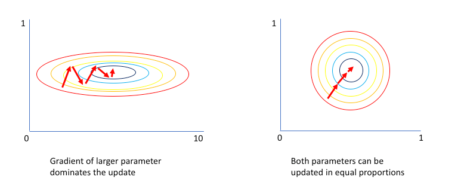

```python
# train_valid_split
def train_test_split(x, y, test_rate = 0.2):
    v_idx = np.random.choice(len(x), size = int(len(x)*test_rate), replace = False)
    t_idx = np.setdiff1d(np.arange(len(x)), v_idx)
    return x[t_idx], y[t_idx], x[v_idx], y[v_idx]

# for minibatch gradient descent
def minibatch(x, y, batch_size = None):
    idx = np.random.choice(len(x), batch_size, replace=False)
    return x[idx], y[idx]
```

```python
train_X, train_Y, test_X, test_Y = train_test_split(train_x_wo, train_y_wo)
```

```python
train_X_n, train_Y_n, test_X_n, test_Y_n = train_test_split(train_x_norm, train_y_norm)
```

```python
n_iter = 10000
n_prt = 500
n_batch = 50
LR = 0.001
```

```python
%%time

init = tf.global_variables_initializer()
sess = tf.Session()
sess.run(init)

loss_record_train = []

for epoch in range(n_iter):
    train_x, train_y = minibatch(train_X, train_Y, n_batch)
    sess.run(optm, feed_dict = {x: train_x, y: train_y, lr: LR})

    if epoch % n_prt == 0:
        cost = sess.run(loss, feed_dict = {x: train_x, y: train_y})
        loss_record_train.append(cost)

        print("Iter {:03d} || train_loss: {:.5f}".format(epoch, cost))
```

```
Iter 000 || train_loss: 30300323840.00000
Iter 500 || train_loss: 1584915456.00000
Iter 1000 || train_loss: 1598354432.00000
Iter 1500 || train_loss: 1065227712.00000
Iter 2000 || train_loss: 1231147520.00000
Iter 2500 || train_loss: 742141440.00000
Iter 3000 || train_loss: 1002632832.00000
Iter 3500 || train_loss: 1253908224.00000
Iter 4000 || train_loss: 526050208.00000
Iter 4500 || train_loss: 591293248.00000
Iter 5000 || train_loss: 1093517184.00000
Iter 5500 || train_loss: 560386240.00000
Iter 6000 || train_loss: 735815296.00000
Iter 6500 || train_loss: 976504000.00000
Iter 7000 || train_loss: 800123648.00000
Iter 7500 || train_loss: 489794720.00000
Iter 8000 || train_loss: 655191808.00000
Iter 8500 || train_loss: 865911104.00000
Iter 9000 || train_loss: 832096896.00000
Iter 9500 || train_loss: 462349600.00000
Wall time: 7.91 s
```

```python
%%time

init = tf.global_variables_initializer()
sess = tf.Session()
sess.run(init)

loss_record_train_n = []

for epoch in range(n_iter):
    train_x, train_y = minibatch(train_X_n, train_Y_n, n_batch)
    sess.run(optm, feed_dict = {x: train_x, y: train_y, lr: LR})

    if epoch % n_prt == 0:
        cost = sess.run(loss, feed_dict = {x: train_x, y: train_y})
        loss_record_train_n.append(cost)

        print("Iter {:03d} || train_loss: {:.5f}".format(epoch, cost))
```

```
Iter 000 || train_loss: 0.05298
Iter 500 || train_loss: 0.00131
Iter 1000 || train_loss: 0.00084
Iter 1500 || train_loss: 0.00079
Iter 2000 || train_loss: 0.00021
Iter 2500 || train_loss: 0.00023
Iter 3000 || train_loss: 0.00007
Iter 3500 || train_loss: 0.00005
Iter 4000 || train_loss: 0.00006
Iter 4500 || train_loss: 0.00007
Iter 5000 || train_loss: 0.00005
Iter 5500 || train_loss: 0.00005
Iter 6000 || train_loss: 0.00006
Iter 6500 || train_loss: 0.00003
Iter 7000 || train_loss: 0.00003
Iter 7500 || train_loss: 0.00003
Iter 8000 || train_loss: 0.00007
Iter 8500 || train_loss: 0.00001
Iter 9000 || train_loss: 0.00029
Iter 9500 || train_loss: 0.00005
Wall time: 7.76 s
```

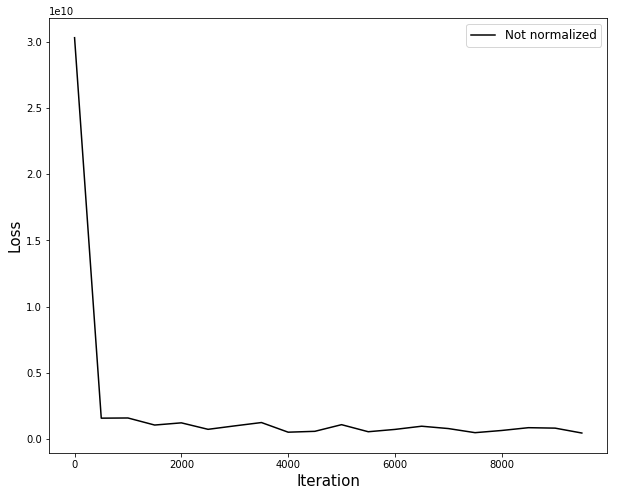

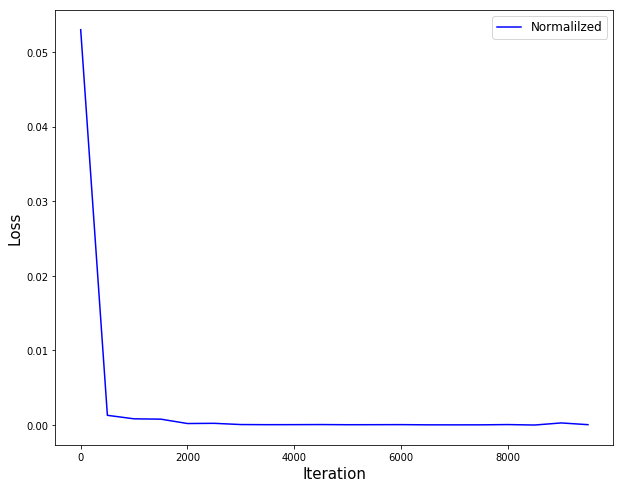

```python
not_n_alpha = 1
n_alpha = 1

plt.figure(figsize=(10,8))
plt.plot(np.arange(len(loss_record_train))*n_prt, loss_record_train, 'k-', alpha = not_n_alpha, label = 'Not normalized')
# plt.plot(np.arange(len(loss_record_train_n))*n_prt, loss_record_train_n, 'b-', alpha = n_alpha,  label = 'Normalilzed')
plt.xlabel('Iteration', fontsize = 15)
plt.ylabel('Loss', fontsize = 15)
# plt.ylim([0, 5])
plt.legend(fontsize = 12)
plt.show()

plt.figure(figsize=(10,8))
# plt.plot(np.arange(len(loss_record_train))*n_prt, loss_record_train, 'k-', alpha = not_n_alpha, label = 'Not normalized')
plt.plot(np.arange(len(loss_record_train_n))*n_prt, loss_record_train_n, 'b-', alpha = n_alpha,  label = 'Normalilzed')
plt.xlabel('Iteration', fontsize = 15)
plt.ylabel('Loss', fontsize = 15)
# plt.ylim([0, 5])
plt.legend(fontsize = 12)
plt.show()
```

# 5. Predictions

```python
test_x = test_X_n
test_y = test_Y_n
test_y
```

```
array([[0.26363226],
       [0.23158925],
       [0.28750323],
       [0.06814839],
       [0.16492258],
       [0.17997634],
       [0.31115914],
       [0.4057828 ],
       [0.15847097],
       [0.40793333],
       [0.37997634],
       [0.25524516],
       [0.48212688],
       [0.36040645],
       [0.11223441],
       [0.30363226],
       [0.14508602],
       [0.28320215],
       [0.19287957],
       [0.31094409],
       [0.24879355],
       [0.30255699],
       [0.73589032],
       [0.52191183],
       [0.29825591],
       [0.17363226],
       [0.28105161],
       [0.10255699],
       [0.20255699],
       [0.42563226],
       [0.27244946],
       [0.17137419],
       [0.47352473],
       [0.2090086 ],
       [0.48320215],
       [0.60309462],
       [0.40793333],
       [0.23804086],
       [0.31115914],
       [0.09503011],
```

[output cut: 207 more lines]

```
       [0.32191183],
       [0.23567527],
       [0.23589032],
       [0.22513763],
       [0.6229871 ],
       [0.26384731],
       [0.23373978],
       [0.27137419],
       [0.21761075],
       [0.19072903],
       [0.40793333],
       [0.2090086 ],
       [0.60148172],
       [0.26277204],
       [0.2229871 ]])
```

```python
my_pred = sess.run(pred, feed_dict = {x: test_x})
my_pred
```

```
array([[0.24962822],
       [0.19967839],
       [0.25569826],
       [0.10988294],
       [0.21480042],
       [0.17404291],
       [0.30608112],
       [0.36193487],
       [0.23124626],
       [0.42651117],
       [0.40141064],
       [0.22792485],
       [0.4495737 ],
       [0.39627576],
       [0.11853963],
       [0.32146505],
       [0.15627895],
       [0.2717735 ],
       [0.2117767 ],
       [0.29843065],
       [0.27768183],
       [0.30029455],
       [0.66411656],
       [0.4898392 ],
       [0.26375872],
       [0.11540431],
       [0.21765724],
       [0.13264877],
       [0.30301964],
       [0.46575832],
       [0.27451536],
       [0.12697452],
       [0.55769676],
       [0.21099979],
       [0.4624325 ],
       [0.63206893],
       [0.39802653],
       [0.25025445],
       [0.32407886],
       [0.14138228],
```

[output cut: 207 more lines]

```
       [0.20119387],
       [0.26185498],
       [0.22247943],
       [0.21946722],
       [0.6255392 ],
       [0.30505767],
       [0.24973932],
       [0.22604486],
       [0.21706039],
       [0.16010761],
       [0.47480857],
       [0.24065882],
       [0.59370726],
       [0.3198407 ],
       [0.24241737]], dtype=float32)
```

```python
test_y_min = x_min[36]
test_y_max = x_max[36]

test_y = (test_y * test_y_max) + test_y_min
my_pred = (my_pred * test_y_max) + test_y_min
```

```python
test_y
```

```
array([[157900.],
       [143000.],
       [169000.],
       [ 67000.],
       [112000.],
       [119000.],
       [180000.],
       [224000.],
       [109000.],
       [225000.],
       [212000.],
       [154000.],
       [259500.],
       [202900.],
       [ 87500.],
       [176500.],
       [102776.],
       [167000.],
       [125000.],
       [179900.],
       [151000.],
       [176000.],
       [377500.],
       [278000.],
       [174000.],
       [116050.],
       [166000.],
       [ 83000.],
       [129500.],
       [233230.],
       [162000.],
       [115000.],
       [255500.],
       [132500.],
       [260000.],
       [315750.],
       [225000.],
       [146000.],
       [180000.],
       [ 79500.],
```

[output cut: 207 more lines]

```
       [185000.],
       [144900.],
       [145000.],
       [140000.],
       [325000.],
       [158000.],
       [144000.],
       [161500.],
       [136500.],
       [124000.],
       [225000.],
       [132500.],
       [315000.],
       [157500.],
       [139000.]])
```

```python
my_pred
```

```
array([[151388.12 ],
       [128161.45 ],
       [154210.69 ],
       [ 86406.56 ],
       [135193.19 ],
       [116240.95 ],
       [177638.72 ],
       [203610.72 ],
       [142840.52 ],
       [233638.69 ],
       [221966.95 ],
       [141296.06 ],
       [244362.77 ],
       [219579.23 ],
       [ 90431.93 ],
       [184792.25 ],
       [107980.71 ],
       [161685.67 ],
       [133787.16 ],
       [174081.25 ],
       [164433.05 ],
       [174947.97 ],
       [344125.2  ],
       [263086.22 ],
       [157958.81 ],
       [ 88974.   ],
       [136521.62 ],
       [ 96992.67 ],
       [176215.14 ],
       [251888.62 ],
       [162960.64 ],
       [ 94354.16 ],
       [294640.   ],
       [133425.9  ],
       [250342.11 ],
       [329223.06 ],
       [220393.33 ],
       [151679.31 ],
       [186007.67 ],
       [101053.76 ],
```

[output cut: 207 more lines]

```
       [128866.15 ],
       [157073.56 ],
       [138763.94 ],
       [137363.25 ],
       [326186.72 ],
       [177162.81 ],
       [151439.78 ],
       [140421.86 ],
       [136244.08 ],
       [109761.04 ],
       [256096.98 ],
       [147217.34 ],
       [311384.88 ],
       [184036.92 ],
       [148035.08 ]], dtype=float32)
```

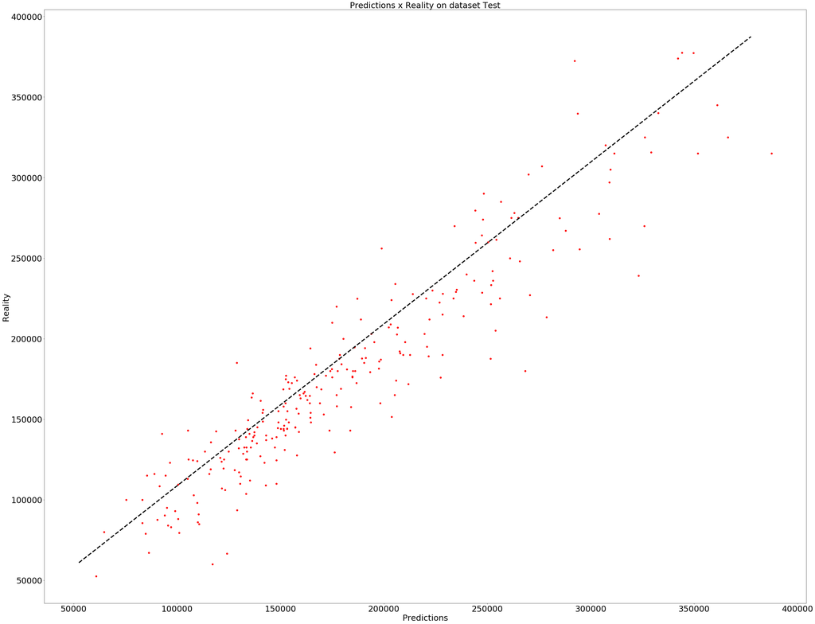

```python
matplotlib.rc('xtick', labelsize=30)
matplotlib.rc('ytick', labelsize=30)

fig, ax = plt.subplots(figsize=(50, 40))

plt.style.use('ggplot')
plt.plot(my_pred, test_y, 'ro')
plt.xlabel('Predictions', fontsize = 30)
plt.ylabel('Reality', fontsize = 30)
plt.title('Predictions x Reality on dataset Test', fontsize = 30)
ax.plot([test_y.min(), test_y.max()], [my_pred.min(), my_pred.max()], 'k--', lw=4)

plt.show()
```